# Spotify Data

Kodi Obika and Eryk Pecyna

May 7, 2019

## Introduction

This is an analysis of the data collected and calculated by Spotify regarding the Billboard Hot 100 songs for the years 1960-2015. The data was calculated using a variety of features and can be found described in more detail here https://www.rdocumentation.org/packages/billboard/versions/0.1.0/topics/spotify_track_data

## Plots of Spotify Data

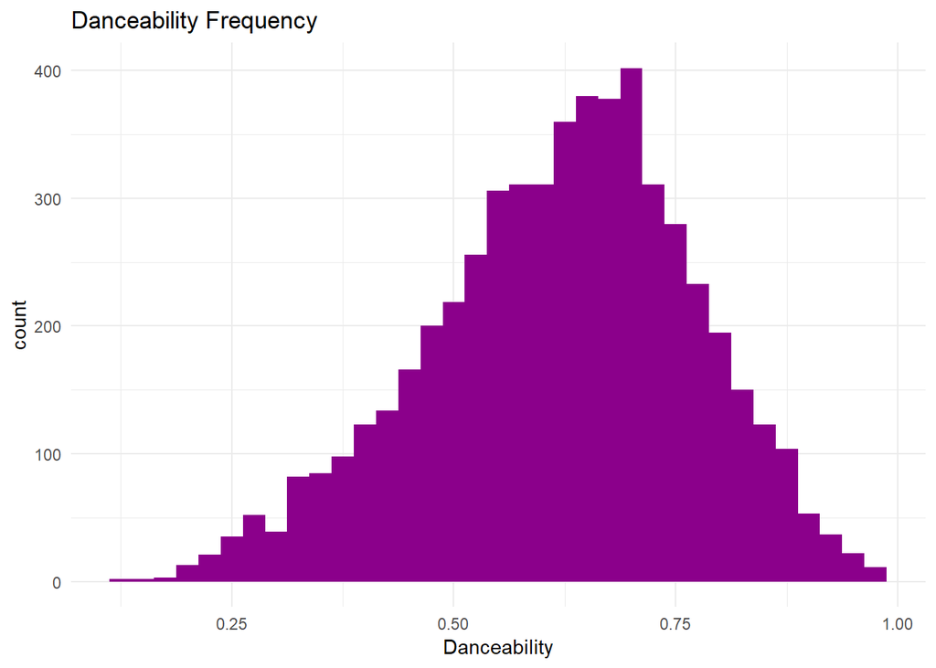

```r
ggplot(data, aes(x = danceability)) +
  geom_histogram(binwidth = 0.025, fill = "darkmagenta") +
  theme_minimal() +
  xlab("Danceability") +
  ggtitle("Danceability Frequency")
```

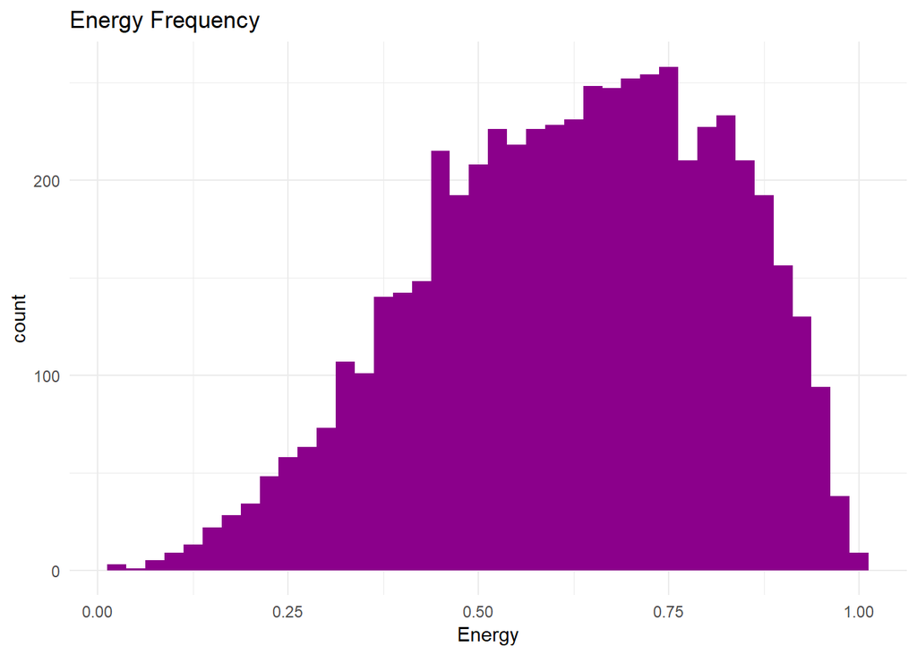

```r
ggplot(data, aes(x = energy)) +
  geom_histogram(binwidth = 0.025, fill = "darkmagenta") +
  theme_minimal() +
  xlab("Energy") +
  ggtitle("Energy Frequency")
```

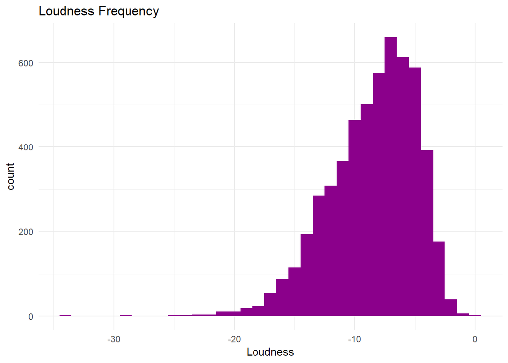

```r
ggplot(data, aes(x = loudness)) +
  geom_histogram(binwidth = 1, fill = "darkmagenta") +
  theme_minimal() +
  xlab("Loudness") +
  ggtitle("Loudness Frequency")
```

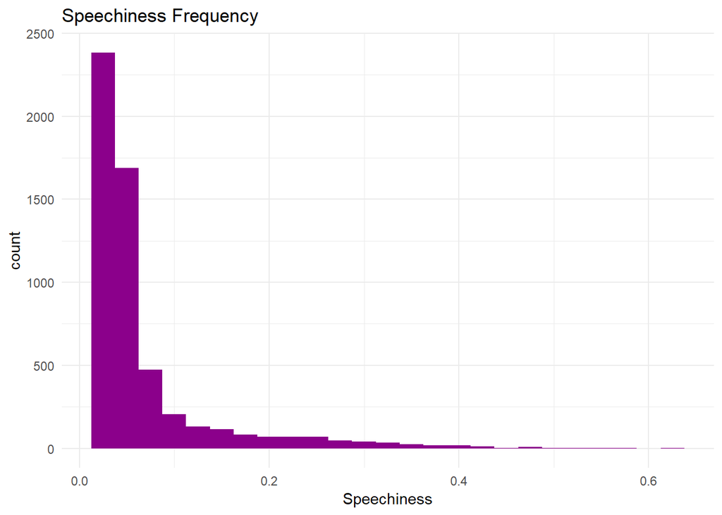

```r
ggplot(data, aes(x = speechiness)) +
  geom_histogram(binwidth = 0.025, fill = "darkmagenta") +
  theme_minimal() +
  xlab("Speechiness") +
  ggtitle("Speechiness Frequency")
```

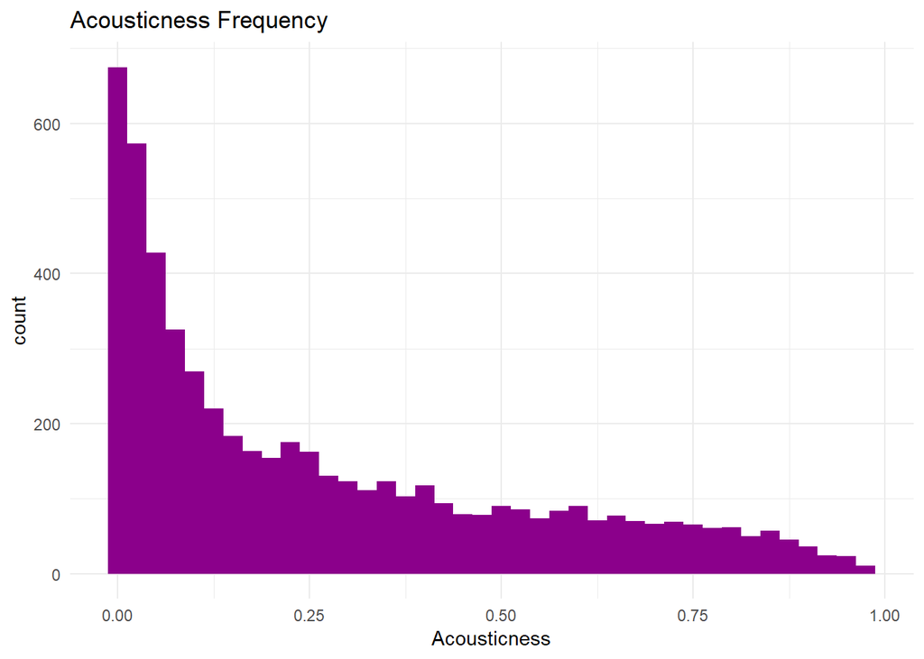

```r
ggplot(data, aes(x = acousticness)) +
  geom_histogram(binwidth = 0.025, fill = "darkmagenta") +
  theme_minimal() +
  xlab("Acousticness") +
  ggtitle("Acousticness Frequency")
```

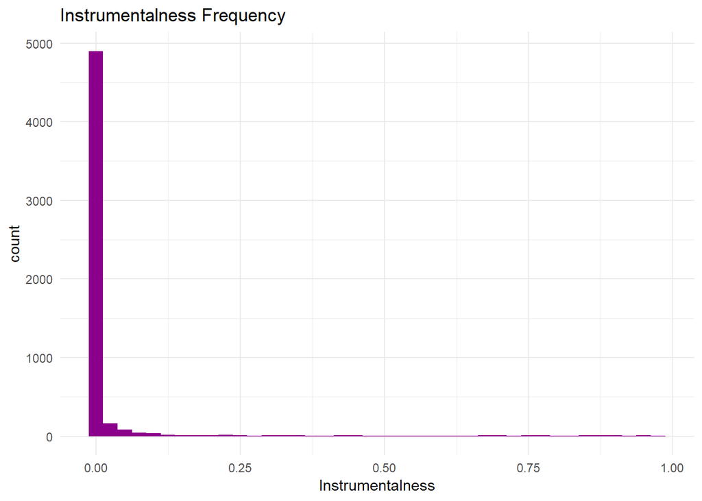

```r
ggplot(data, aes(x = instrumentalness)) +
  geom_histogram(binwidth = 0.025, fill = "darkmagenta") +
  theme_minimal() +
  xlab("Instrumentalness") +
  ggtitle("Instrumentalness Frequency")
```

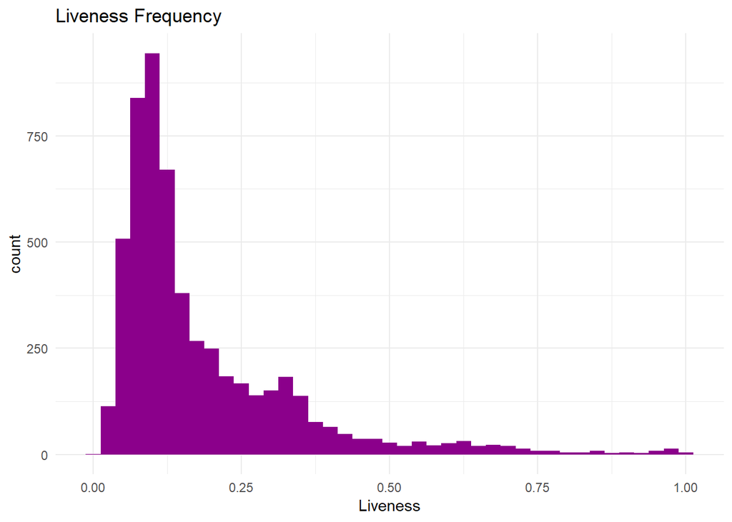

```r
ggplot(data, aes(x = liveness)) +
  geom_histogram(binwidth = 0.025, fill = "darkmagenta") +
  theme_minimal() +
  xlab("Liveness") +
  ggtitle("Liveness Frequency")
```

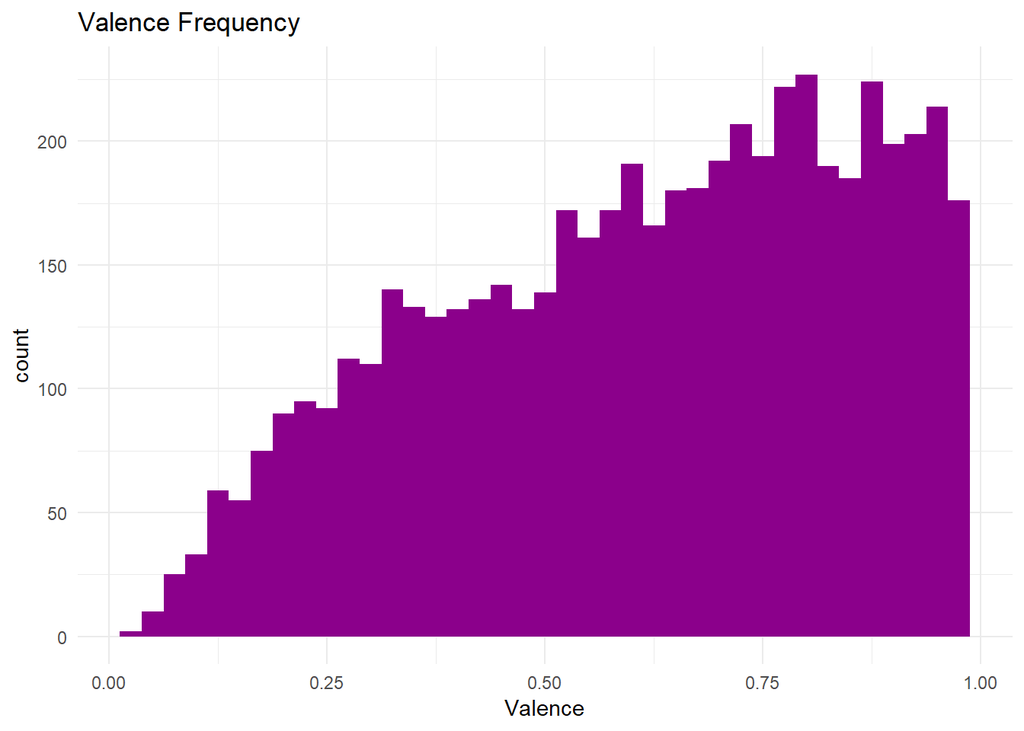

```r
ggplot(data, aes(x = valence)) +
  geom_histogram(binwidth = 0.025, fill = "darkmagenta") +
  theme_minimal() +
  xlab("Valence") +
  ggtitle("Valence Frequency")
```

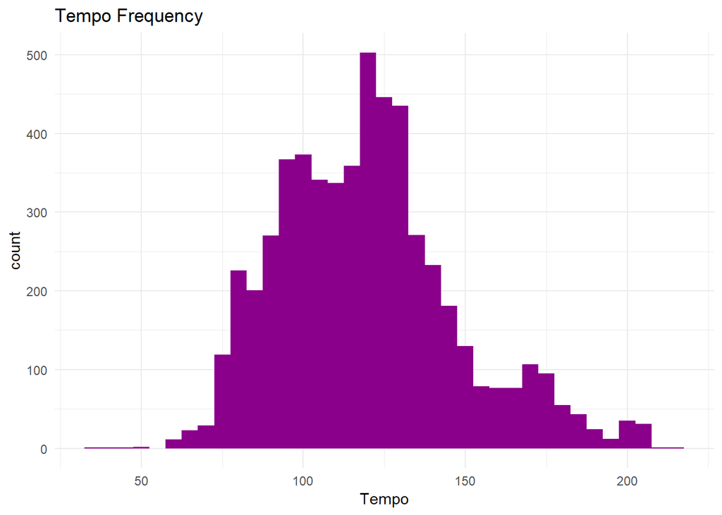

```r
ggplot(data, aes(x = tempo)) +
  geom_histogram(binwidth = 5, fill = "darkmagenta") +
  theme_minimal() +
  xlab("Tempo") +
  ggtitle("Tempo Frequency")
```

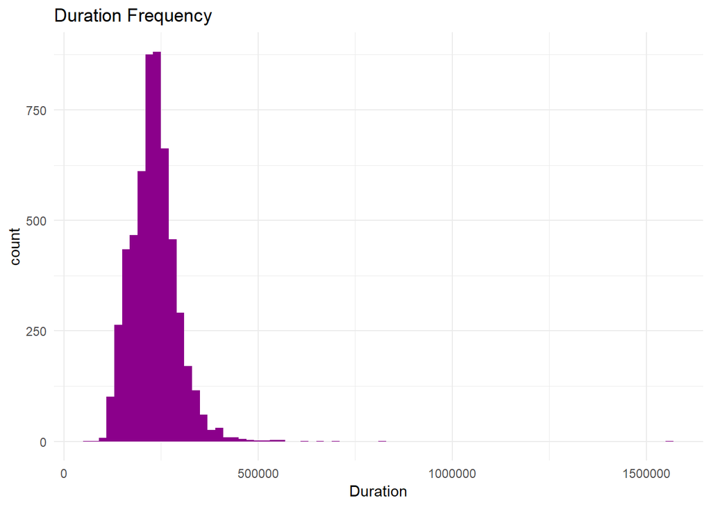

```r
ggplot(data, aes(x = duration_ms)) +
  geom_histogram(binwidth = 20000, fill = "darkmagenta") +
  theme_minimal() +
  xlab("Duration") +
  ggtitle("Duration Frequency")
```

## Representation of each key

This displays the counts of songs that were written in each key.

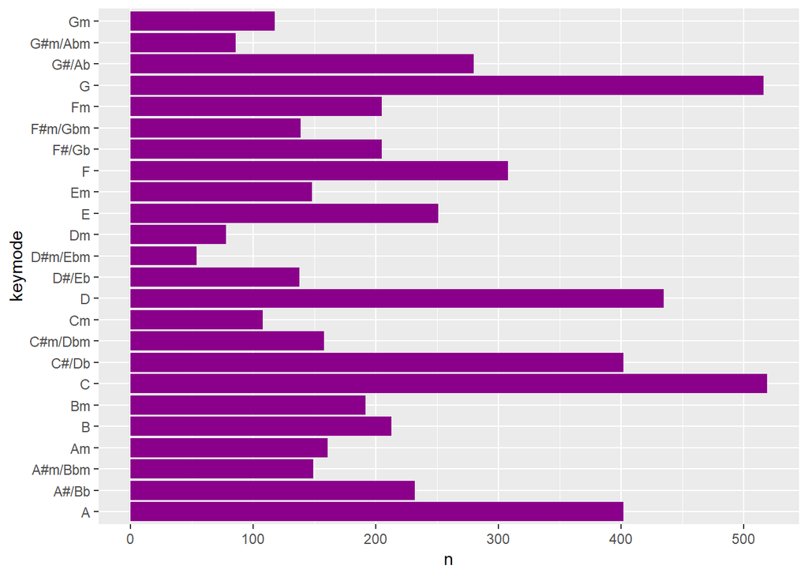

```r
keymode_lab <- c("C", "Cm", "C#/Db", "C#m/Dbm", "D", "Dm", "D#/Eb",
                 "D#m/Ebm", "E", "Em", "F", "Fm", "F#/Gb", "F#m/Gbm",
                 "G", "Gm", "G#/Ab", "G#m/Abm", "A", "Am", "A#/Bb",
                 "A#m/Bbm", "B", "Bm")

data %>%
  select(key, mode) %>%
  group_by(key, mode) %>%
  mutate(n = n()) %>%
  unique() %>%
  arrange(key) %>%
  ungroup() %>%
  mutate(keymode = keymode_lab) %>%
  select(keymode, n) %>%
  ggplot(aes(x = keymode, y = n)) +
  geom_bar(stat = "identity", fill = "darkmagenta") +
  coord_flip()
```

## Are danceable songs more explicit?

The P-value is tiny because it is extremely unlikely to observe such a difference by random chance. This means that explicit songs are much more likely to be danceable than non-explicit songs.

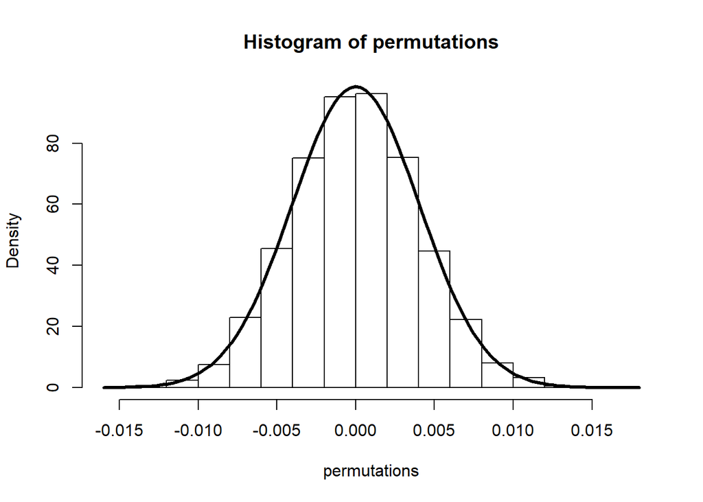

```
## [1] "p-value:"
## [1] 0
```

```r
perm.test(data$danceability, data$explicit, FALSE, 10000)
```

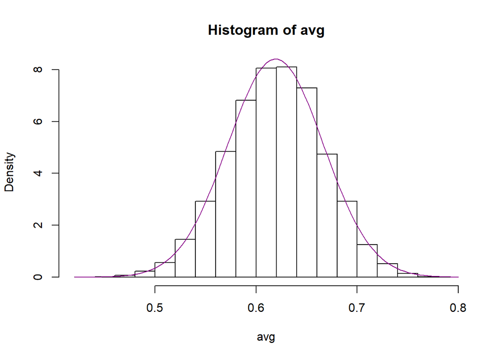

```r
clt(data$danceability)
```

## Linear Regression

Here we use a Projection Matrix approach to calculate linear regression

```r
Attributes <- cbind(data$danceability, data$energy, data$loudness,
                    data$speechiness, data$acousticness, data$instrumentalness,
                    data$liveness, data$valence, data$tempo)

numericalData <- (cbind(data$Position, Attributes))

N <- ncol(numericalData)
means <- numeric(N)
for(i in 1:N) {
  means[i] <- meancorrelation(numericalData, i)
}
```

The third column, which happens to be energy in our definition of numericalData, has the highest average correlation with the other columns. The following linear regressions are the highest correlations energy has with any other columns.

```r
means
```

```
##  [1] 0.0001557784 0.0517591576 0.1185555264 0.0810192233 0.0185416844
##  [6] 0.0738156165 0.0029339426 0.0048564297 0.0454211456 0.0078399801
```

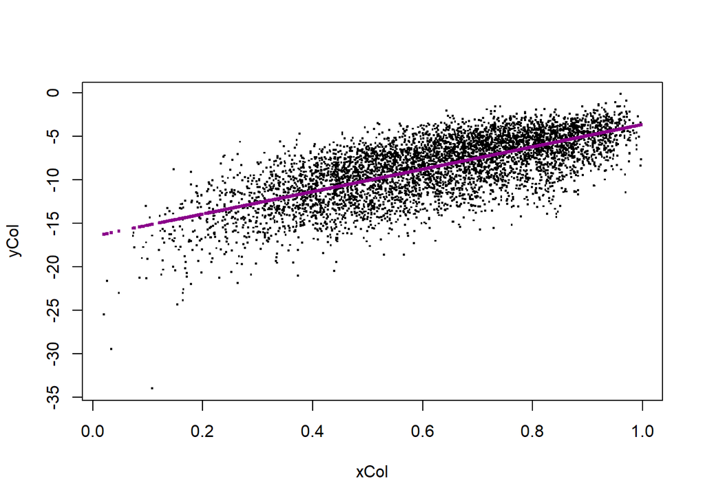

```
## [1] "Correlation:"
## [1] 0.4870119
```

```
## [1] 0.4870119
```

```r
linreg(data$energy, data$loudness)
```

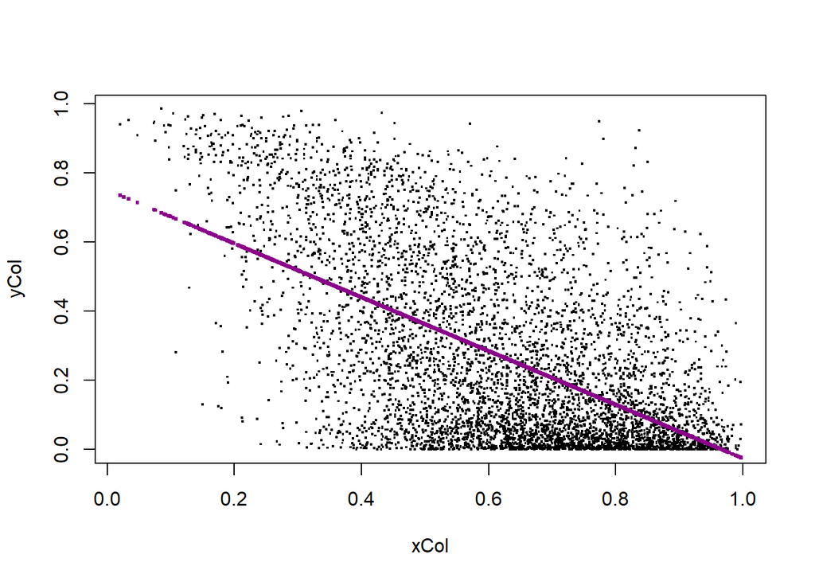

```
## [1] "Correlation:"
## [1] 0.3300696
```

```
## [1] 0.3300696
```

```r
linreg(data$energy, data$acousticness)
```

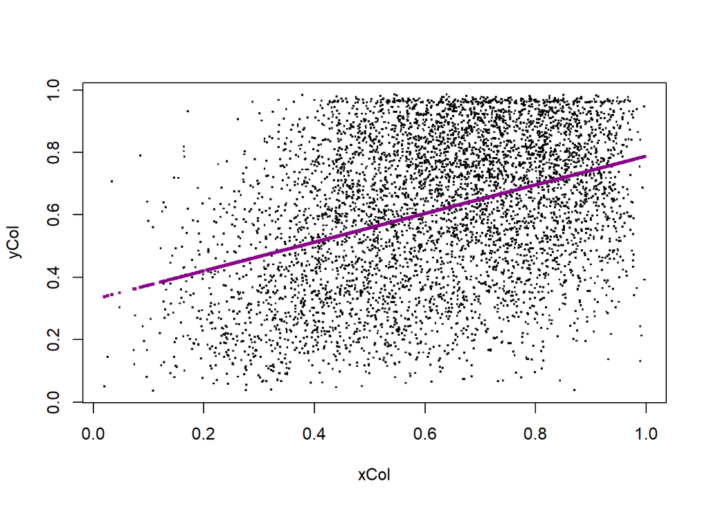

```
## [1] "Correlation:"
## [1] 0.1380401
```

```
## [1] 0.1380401
```

```r
linreg(data$energy, data$valence)
```

## Principal Components Analysis

Here we will use Principal Componenets Analysis to see if we can reconstruct any of the columns after stripping some of the eigenvectors of the basis of eigenvectors formed from the covariance matrix.

```r
head(PCA(Attributes)); head(Attributes)
```

```
##           [,1]      [,2]      [,3]       [,4]      [,5]       [,6]
## [1,] 0.6444400 0.5954898 -8.775389 0.06471767 0.2849463 0.02815717
## [2,] 0.6551767 0.5836274 -8.886802 0.06322897 0.2926858 0.02798872
## [3,] 0.6188049 0.6238128 -8.509380 0.06827211 0.2664674 0.02855937
## [4,] 0.6398161 0.6005986 -8.727408 0.06535880 0.2816132 0.02822971
## [5,] 0.6346883 0.6062640 -8.674198 0.06606979 0.2779169 0.02831017
## [6,] 0.6129943 0.6302326 -8.449085 0.06907778 0.2622789 0.02865053
##           [,7]      [,8]      [,9]
## [1,] 0.1799445 0.5964657  92.59154
## [2,] 0.1785194 0.5887902  81.11245
## [3,] 0.1833469 0.6147918 119.99912
## [4,] 0.1805582 0.5997712  97.53514
## [5,] 0.1812388 0.6034370 103.01746
## [6,] 0.1841181 0.6189456 126.21143
```

```
##       [,1]  [,2]    [,3]   [,4]  [,5]     [,6]  [,7]  [,8]    [,9]
## [1,] 0.466 0.389 -12.825 0.0253 0.631 8.43e-01 0.295 0.745  92.631
## [2,] 0.554 0.186 -15.846 0.0379 0.909 1.44e-03 0.110 0.200  81.181
## [3,] 0.758 0.462  -8.952 0.0482 0.790 1.25e-05 0.170 0.726 120.004
## [4,] 0.583 0.168 -12.426 0.0350 0.869 0.00e+00 0.148 0.353  97.572
## [5,] 0.567 0.141 -14.803 0.0315 0.925 4.65e-03 0.117 0.315 103.078
## [6,] 0.635 0.391 -14.140 0.0367 0.511 2.47e-03 0.493 0.713 126.267
```

```r
head(PCA(Attributes, 2)); head(Attributes)
```

```
##           [,1]      [,2]       [,3]       [,4]      [,5]       [,6]
## [1,] 0.6213111 0.4429632 -12.837851 0.05025650 0.4064455 0.04802988
## [2,] 0.6154502 0.3216449 -15.864561 0.03839019 0.5013750 0.06212244
## [3,] 0.6161741 0.6064635  -8.971469 0.06662721 0.2802875 0.03081981
## [4,] 0.6186107 0.4607564 -12.452028 0.05210025 0.3930083 0.04644977
## [5,] 0.5996612 0.3752722 -14.826537 0.04416927 0.4619197 0.05840611
## [6,] 0.5805843 0.4164997 -14.141742 0.04881359 0.4325336 0.05649781
##           [,7]      [,8]      [,9]
## [1,] 0.1711127 0.5843005  92.63119
## [2,] 0.1633498 0.5678951  81.18057
## [3,] 0.1823423 0.6134080 120.00363
## [4,] 0.1724609 0.5886177  97.57150
## [5,] 0.1678636 0.5850136 103.07752
## [6,] 0.1717423 0.6018988 126.26700
```

```
##       [,1]  [,2]    [,3]   [,4]  [,5]     [,6]  [,7]  [,8]    [,9]
## [1,] 0.466 0.389 -12.825 0.0253 0.631 8.43e-01 0.295 0.745  92.631
## [2,] 0.554 0.186 -15.846 0.0379 0.909 1.44e-03 0.110 0.200  81.181
## [3,] 0.758 0.462  -8.952 0.0482 0.790 1.25e-05 0.170 0.726 120.004
## [4,] 0.583 0.168 -12.426 0.0350 0.869 0.00e+00 0.148 0.353  97.572
## [5,] 0.567 0.141 -14.803 0.0315 0.925 4.65e-03 0.117 0.315 103.078
## [6,] 0.635 0.391 -14.140 0.0367 0.511 2.47e-03 0.493 0.713 126.267
```

```r
head(PCA(Attributes, 8)); head(Attributes)
```

```
##           [,1]      [,2]       [,3]        [,4]      [,5]         [,6]
## [1,] 0.4694079 0.3896147 -12.824979 0.005994648 0.6309188 0.8425741690
## [2,] 0.5545167 0.1860932 -15.845997 0.034972929 0.9089877 0.0013754356
## [3,] 0.7526514 0.4610352  -8.952033 0.078499234 0.7901275 0.0006808303
## [4,] 0.5814782 0.1677255 -12.426009 0.043620891 0.8690363 0.0001901567
## [5,] 0.5658808 0.1407981 -14.803007 0.037840192 0.9250267 0.0047898498
## [6,] 0.6279112 0.3897213 -14.140044 0.076857428 0.5111690 0.0033557791
##           [,7]      [,8]      [,9]
## [1,] 0.2964954 0.7441541  92.63101
## [2,] 0.1102267 0.1998717  81.18100
## [3,] 0.1676530 0.7273276 120.00399
## [4,] 0.1473322 0.3533777  97.57200
## [5,] 0.1165089 0.3152778 103.07800
## [6,] 0.4898893 0.7147596 126.26699
```

```
##       [,1]  [,2]    [,3]   [,4]  [,5]     [,6]  [,7]  [,8]    [,9]
## [1,] 0.466 0.389 -12.825 0.0253 0.631 8.43e-01 0.295 0.745  92.631
## [2,] 0.554 0.186 -15.846 0.0379 0.909 1.44e-03 0.110 0.200  81.181
## [3,] 0.758 0.462  -8.952 0.0482 0.790 1.25e-05 0.170 0.726 120.004
## [4,] 0.583 0.168 -12.426 0.0350 0.869 0.00e+00 0.148 0.353  97.572
## [5,] 0.567 0.141 -14.803 0.0315 0.925 4.65e-03 0.117 0.315 103.078
## [6,] 0.635 0.391 -14.140 0.0367 0.511 2.47e-03 0.493 0.713 126.267
```

```r
head(PCA(Attributes, 9)); head(Attributes)
```

```
##       [,1]  [,2]    [,3]   [,4]  [,5]          [,6]  [,7]  [,8]    [,9]
## [1,] 0.466 0.389 -12.825 0.0253 0.631  8.430000e-01 0.295 0.745  92.631
## [2,] 0.554 0.186 -15.846 0.0379 0.909  1.440000e-03 0.110 0.200  81.181
## [3,] 0.758 0.462  -8.952 0.0482 0.790  1.250000e-05 0.170 0.726 120.004
## [4,] 0.583 0.168 -12.426 0.0350 0.869 -6.591949e-17 0.148 0.353  97.572
## [5,] 0.567 0.141 -14.803 0.0315 0.925  4.650000e-03 0.117 0.315 103.078
## [6,] 0.635 0.391 -14.140 0.0367 0.511  2.470000e-03 0.493 0.713 126.267
```

```
##       [,1]  [,2]    [,3]   [,4]  [,5]     [,6]  [,7]  [,8]    [,9]
## [1,] 0.466 0.389 -12.825 0.0253 0.631 8.43e-01 0.295 0.745  92.631
## [2,] 0.554 0.186 -15.846 0.0379 0.909 1.44e-03 0.110 0.200  81.181
## [3,] 0.758 0.462  -8.952 0.0482 0.790 1.25e-05 0.170 0.726 120.004
## [4,] 0.583 0.168 -12.426 0.0350 0.869 0.00e+00 0.148 0.353  97.572
## [5,] 0.567 0.141 -14.803 0.0315 0.925 4.65e-03 0.117 0.315 103.078
## [6,] 0.635 0.391 -14.140 0.0367 0.511 2.47e-03 0.493 0.713 126.267
```